# ST313_Summative2_23007

David

03/12/2023

```r
library(ggplot2)
library(tidyr)
```

**The motivating question, “Are causal models the solution to making discriminatory algorithms e.g Ant colony Optimisation (ACO) fall in line with the Belmont principles?”**

The aim of this report is to use to Belmont principles to judge the fairness of a path finding algorithm. If it’s a discriminatory algorithm then how can we use causal models as a corrective tool. By acknowledging cause and effect relationships at play we can make adjustments to the algorithm so that its outcomes meet ethical and equitable standards that are universally or at least commonly accepted in the data science field.

If discriminatory path optimising algorithms, in the context of resource allocation, can worsen the socio-economic climate of a region.It becomes a form of systemic bias towards marginalised groups who historically face challenges with issues such as low economic output, poor infrastructure and high crime rates. If the algorithm ignores these underserved communities, then it directly exacerbates disparities within a population.

Definitions:

1. **Causal Models:**
   - **Definition:** Causal models are frameworks that show case the cause-and-effect relationships within a system.

They’re important to this report because they can help identify which factors contribute to inequitable outcomes that are perpetrated by an algorithm.

2. **Belmont Principles:**
   - **Definition:** The Belmont report provides equitable and ethical standards we can use to judge our resource allocating algorithms.
   - **The principles:**
     - *Respect for Persons:* This has 2 considerations. All individuals should be treated as autonomous agents. And that those with diminished autonomy deserve protection.
     - *Beneficence:* The actions that are taken should maximise potential benefit and minimise potential harm.
     - *Justice:* There are several criteria to distribute burdens and benefits. Distribution must happen on the basis of equal share, individual need, individual effort, societal contribution and merit

Source - https://www.hhs.gov/ohrp/regulations-and-policy/belmont-report/read-the-belmont-report/index.html#:~:text=Three%20basic%20principles%2C%20among%20those,1.

3. **Unfair Algorithms:**
   - **Definition:** Algorithms that discriminate against disadvantaged groups based on characteristics such as race, gender, religion, nationality or socio-economic status.
   - **Explanation:** If left unchecked these may worsen situations they were intended to fix.
4. **Ant Colony Optimsation Algorithm:**
- **Definition:** Its an algorithm that decided on the optimality of a path based of the frequency of its use. The more a path is used the higher its pheromone level is, modeled after an actual ant colony with intricate path networks. Higher pheromone paths must be used frequently for a reason and so these paths are preferred by the algorithm. In my simulations I will use a simpler version.
  - **Explanation:** By optimising paths, we can use this algorithm for our resource allocation hypothetical scenario.

**Hypothetical Scenario:**

I will describe the scenario as a short narrative from the perspective of someone disadvantages by the ACO algorithm.

Once upon a time, in a busy world connected by transport networks, there was a resource allocating algorithm called the Ant Colony Optimisation (ACO). It was inspired by how ants find food efficiently and build their intricate base of tunnels.

**Act 1: ACO Arrives**

ACO came in to make routes better, promising efficiency and improved resource sharing. However, the creators didn’t pay much attention to the old data that made this algorithm. This data, a look at the past, had biases and unfairness hidden in it, without the algorithm’s creators knowing.

**Act 2: Things seem fine at first**

As ACO started working, it liked the paths based on old biases. Me and others in my area noticed a small change. Even though our routes were efficient, they got ignored for the old ones. The algorithm, following old favorites, systematically favored nonoptimal paths, benefiting those communities while marginalising others.

**Act 3: The Bias**

Every time it worked, the algorithm made these biases stronger. The pheromone trails that guided the algorithm got stronger, making them frequent those routes. Our once lively area got left out, as the algorithm, following biased data, kept ignoring the paths to our homes.

**Act 4: The Consequences**

We didn’t get the same access to important resources, opportunities to grow, and felt ignored all the time. The idea of a better distribution network turned into an unfair reality that worsened our our economic output and infrastructure which increased crime rates. The algorithm factored this into its calculations resulting in a downward spiral where we get treated worse, become worse and so are judged as worse.

**Act 5: Causal Models**

Upon realising their mistakes the creators introduced causal models to understand why there were biased outcomes. They wanted to fix the algorithm and make it fair.

**Simulations to make discriminatory algorithms fair by abiding to the Belmont Report:**

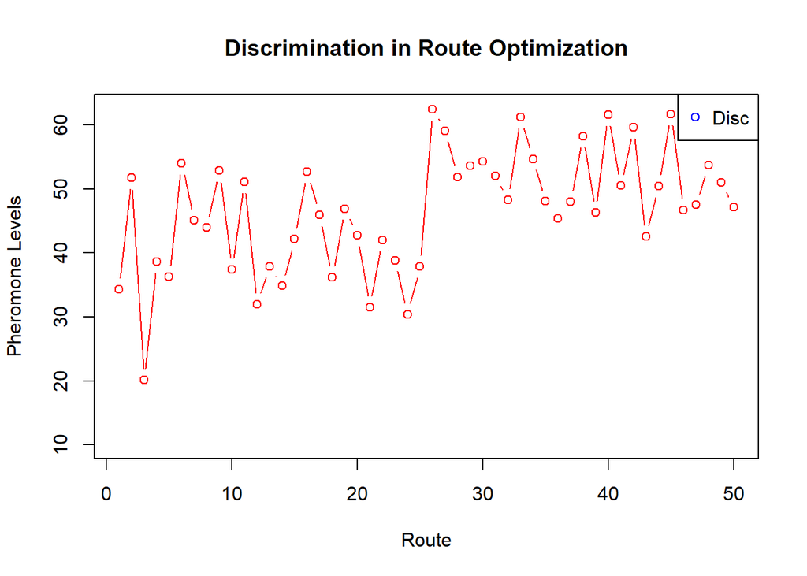

```r
# Simulate data with biases - Segmenting routes, applying pheromone threshold, and allocating resources
set.seed(23007)

route = 1:50
town_segment = rep(1:2, each = 25)
historical_region_pref = rnorm(50, mean = 5, sd = 2)

infra_quality = ifelse(town_segment == 1, rnorm(25, mean = 60, sd = 10), rnorm(25, mean = 80, sd = 10))

economic_output = ifelse(town_segment == 1, rnorm(25, mean = 90, sd = 20), rnorm(25, mean = 110, sd = 20))

crime_rates = ifelse(town_segment == 1, rnorm(25, mean = 6, sd = 2), rnorm(25, mean = 4, sd = 1))


historical_data_disc <- data.frame(
  route,
  town_segment,  # Segmenting routes into two towns evenly
  historical_region_pref,  # Simulated historical region preferences
  infra_quality,
  economic_output,
  crime_rates
)

# Discriminatory biases in assigning pheromone levels - Segment-specific biases
pheromones_disc <-
  historical_data_disc$historical_region_pref +
  0.2 * historical_data_disc$infra_quality +
  0.3 * historical_data_disc$economic_output -
  0.5 * historical_data_disc$crime_rates

# Pheromone threshold - Routes with low pheromone levels won't be used
pheromone_threshold <- 40
historical_data_disc$selected_routes <- ifelse(pheromones_disc > pheromone_threshold, 1, 0)

# Resource allocation based on pheromone levels
resource_allocation <- pheromones_disc * 6  # Multiplier
historical_data_disc$resources_sent <- historical_data_disc$selected_routes * resource_allocation

#When causal models underlying the generation of the data are not acknowledged, it can lead to the algorithm discriminating against certain routes and their communities because they fall short on metrics that are unfair to judge them on.





# Visualisation of Pheromone Levels
plot(historical_data_disc$route, pheromones_disc, type = 'b', col = 'red',
     ylim = c(10, max(pheromones_disc) + 0.2),
     main = 'Discrimination in Route Optimization',
     xlab = 'Route', ylab = 'Pheromone Levels')
legend('topright', legend = 'Disc', col = 'blue', pch = 1)
```

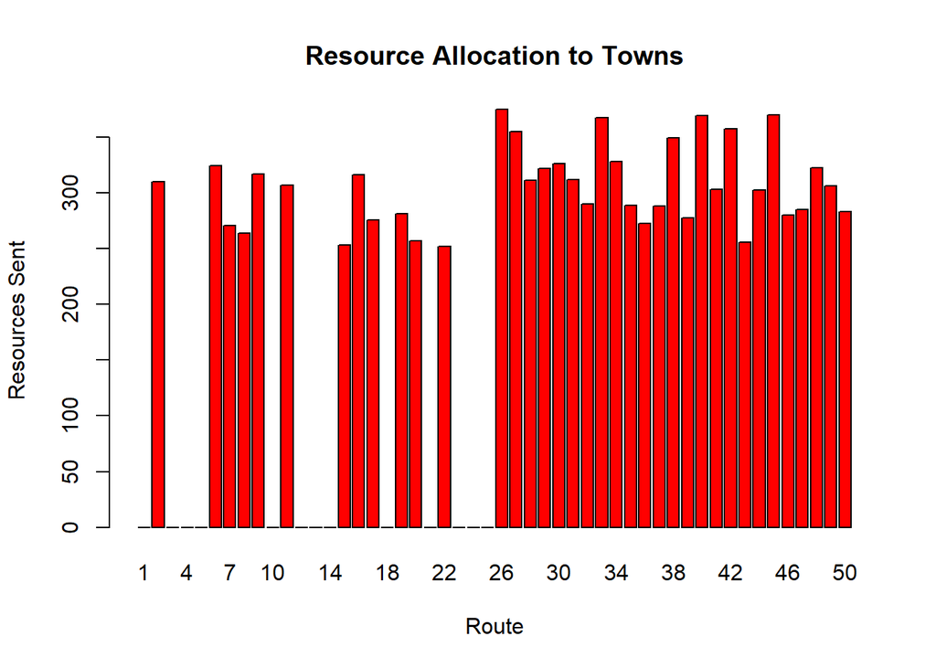

```r
# Visualisation of Resource Allocation
barplot(historical_data_disc$resources_sent, names.arg = historical_data_disc$route,
        col = 'red', main = 'Resource Allocation to Towns',
        xlab = 'Route', ylab = 'Resources Sent')
```

```r
#Graph 1 demonstrates the disparity in routes that pass the pheromone threshold between town 1 and town 2.

#Graph 2 shows that many routes in town 1 are ignored by the algorithm, receiving no resources (a form of systematic discrimination).
```

**Discriminatory Simulation:**

Based of the graph we see most of town 1 receives either nothing or much less resources in comparison to town 2. This is because the algorithm discriminates against town 1 by overlooking the historical context/biases that are the true cause of their poor infrastructure and economic output as well as high crime rates. Due to the unjust disparity in resources sent between both towns, its evident that town 1 receives unfair treatment